#Final Exam, Statistical Analysis And Document Mining, Complementary Course

#Author : Maelig Hurte, M1AM

####Part 1 : Multiple linear regression for prostate cancer

###Question 1 : Preliminary analysis of the data

$\bullet$ First of all, we just load data and have a first look of it to get an idea on the correlation between the prostate cancer represented by the tumor volume (lcavol) with other parameters. In order to get a overview of the problem, we drew a scatter plot with the following code.

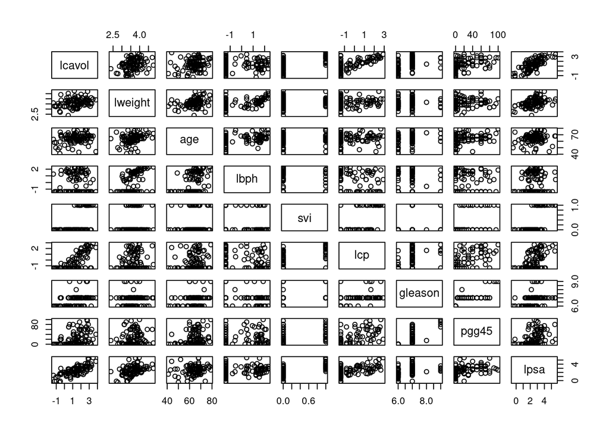

```r
#We set a random seed for reproducibility of all results
set.seed(2523)
prostateCancer <- read.table("./prostate.data", header=T)
attach(prostateCancer)
prostateCancer <- prostateCancer[, -10]
pairs(prostateCancer)
```

- Reading the graphs, we cannot conclude, yet we can be confident that capsular penetration (lcp) and prostate specific antigen (lpsa) are related to tumor volume. This relation seems to be linear between their logarithms. Some other variables can seem related but it is harder to conclude and less obvious at first glance.

$\bullet$ Back to our goal, we would like to have a linear model so we want to analyse if datas are linearly related with each other, an indicator of that is the correlation. So to have a better idea of which variable are linearly dependent we analyse the correlation between these with the following code.

```r
cor(prostateCancer)
```

```
##            lcavol    lweight       age         lbph         svi          lcp
## lcavol  1.0000000 0.28052138 0.2249999  0.027349703  0.53884500  0.675310484
## lweight 0.2805214 1.00000000 0.3479691  0.442264399  0.15538490  0.164537142
## age     0.2249999 0.34796911 1.0000000  0.350185896  0.11765804  0.127667752
## lbph    0.0273497 0.44226440 0.3501859  1.000000000 -0.08584324 -0.006999431
## svi     0.5388450 0.15538490 0.1176580 -0.085843238  1.00000000  0.673111185
## lcp     0.6753105 0.16453714 0.1276678 -0.006999431  0.67311118  1.000000000
## gleason 0.4324171 0.05688209 0.2688916  0.077820447  0.32041222  0.514830063
## pgg45   0.4336522 0.10735379 0.2761124  0.078460018  0.45764762  0.631528246
## lpsa    0.7344603 0.43331938 0.1695928  0.179809404  0.56621822  0.548813175
##            gleason      pgg45      lpsa
## lcavol  0.43241706 0.43365225 0.7344603
## lweight 0.05688209 0.10735379 0.4333194
## age     0.26889160 0.27611245 0.1695928
## lbph    0.07782045 0.07846002 0.1798094
## svi     0.32041222 0.45764762 0.5662182
## lcp     0.51483006 0.63152825 0.5488132
## gleason 1.00000000 0.75190451 0.3689868
## pgg45   0.75190451 1.00000000 0.4223159
## lpsa    0.36898681 0.42231586 1.0000000
```

- So we can notice that the most correlated variables to lpsa are lcavol, svi and lcp as the scatter plot has shown. Conversely, age and lbph has a very small correlation with lpsa, and we can anticipate that this factor in linear regression will be near 0.
- In conclusion, this first paragraph gave us a quick overview of the linear dependencies, and as of now, it seems lcavol and lcp are the most relevant. Next, we are going to fit a linear regression.

###Question 2 : Linear Regression

$\square$ In this exercise we will compute the linear regression to obtain a first predictor and analyse the results.

## Linear predictive model for lcavol

- Compute a linear regression is to find $Y = \epsilon + \beta_0+\beta_1.lweight+\beta_2.age+...+\beta_10.lcp$
- Before computing the linear regression we have to remember that gleason and svi are qualitative variable. We have to consider that because it is a general variable used in medicine to have a quick qualification of the general condition of the patient. After that we can compute the multilinear regression. We do that with the following code :

```r
prostateCancer$gleason<-factor(prostateCancer$gleason)
prostateCancer$svi<-factor(prostateCancer$svi)
model <- lm(lpsa ~ ., data = prostateCancer)
summary(model)
```

```
##
## Call:
## lm(formula = lpsa ~ ., data = prostateCancer)
##
## Residuals:
##      Min       1Q   Median       3Q      Max
## -1.77956 -0.31691 -0.04774  0.44278  1.52832
##
## Coefficients:
##              Estimate Std. Error t value Pr(>|t|)
## (Intercept)  0.486274   0.885929   0.549  0.58451
## lcavol       0.549532   0.090087   6.100 2.94e-08 ***
## lweight      0.623816   0.200463   3.112  0.00252 **
## age         -0.023103   0.011282  -2.048  0.04364 *
## lbph         0.091523   0.058454   1.566  0.12108
## svi1         0.744537   0.244602   3.044  0.00310 **
## lcp         -0.124612   0.094565  -1.318  0.19109
## gleason7     0.253874   0.216141   1.175  0.24341
## gleason8     0.480520   0.760895   0.632  0.52938
## gleason9    -0.036003   0.494866  -0.073  0.94217
## pgg45        0.004902   0.004622   1.061  0.29184
## ---
## Signif. codes:  0 '***' 0.001 '**' 0.01 '*' 0.05 '.' 0.1 ' ' 1
##
## Residual standard error: 0.6973 on 86 degrees of freedom
## Multiple R-squared:  0.6731, Adjusted R-squared:  0.6351
## F-statistic: 17.71 on 10 and 86 DF,  p-value: < 2.2e-16
```

We should point out that our factor Gleason has become Gleason 7, Gleason 8, and Gleason 9. This is because we have declared it as a qualitative variable. We have three variables named GleasonX that take a value of 1 if the Gleason score is X, and 0 if it is not. The same applies for SVI.

The linear regression is good. The p-value is small ($10^{-16}$), and the residual standard error is correct.

## Confidence interval

$\square$ We obtained an estimation of the coefficients and now we will compute their $95%$ confidence intervals to have an idea on the accuracy.

```r
confint(model, level = 0.95)
```

```
##                   2.5 %        97.5 %
## (Intercept) -1.27489572  2.2474431917
## lcavol       0.37044589  0.7286179787
## lweight      0.22530925  1.0223228506
## age         -0.04553080 -0.0006743801
## lbph        -0.02467895  0.2077247952
## svi1         0.25828392  1.2307901206
## lcp         -0.31260085  0.0633761086
## gleason7    -0.17580081  0.6835482283
## gleason8    -1.03208983  1.9931305197
## gleason9    -1.01976358  0.9477579466
## pgg45       -0.00428630  0.0140911264
```

-> lcavol has a confidence interval that is clearly positive and far from zero, which confirms its correlation with lpsa. Same thing for svi1 and lweight.

-> lcp and gleason7 have interesting values but their proximity to zero makes it difficult to confirm a strong relation with lpsa yet.

-> age had the smallest correlation with lpsa so it is unsurprisingly close to 0.

## lpsa variable

- We said that lpsa is most correlated to lcavol so we can assume that it is the most relevant in our linear regression.

-> To sum up the information, it is the most correlated variable to lcavol, we have a p-values between 0 and 0.001 (given in the summary of linear regression before), a largely positive confidence interval of length 0,4. It is therefore an important variable in our linear regression, and it is coherent because we want linear dependency and it is the most correlated variable to lcavol.

## Predicted values

$\square$ We have made some comments on the coefficients for our linear regression, but we have not yet assessed the quality of our model. To do so, we will first plot the predicted values against the actual values.

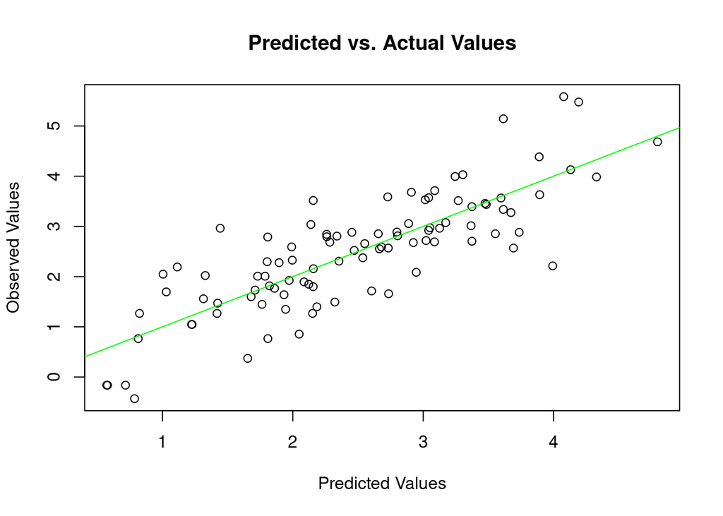

$\bullet$ Now we want to validate the normality assumption of the residuals :

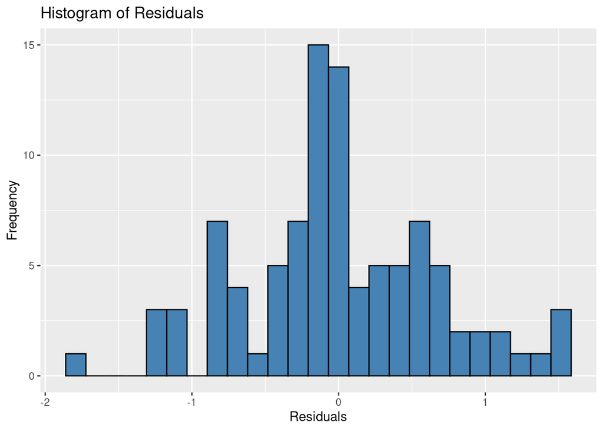

```r
library(ggplot2)
ggplot(data = prostateCancer, aes(x = model$residuals)) +
    geom_histogram(bins=25,fill = 'steelblue', color = 'black') +
    labs(title = 'Histogram of Residuals', x = 'Residuals', y = 'Frequency')
```

-> According to this histogram, the residuals have a normal allure around the value 0, therefore, we can admit the supposition that the residuals follow a normal distribution.

To convince ourselves, we can validate using the Shapiro-Will test with the “shapiro.test()” command.

```r
shapiro.test(x = model$residuals)
```

```
##
##  Shapiro-Wilk normality test
##
## data:  model$residuals
## W = 0.98413, p-value = 0.2939
```

- In this test the null hypothesis is that the population is normally distributed.

Hence, with a a large p-values such as $0.2939$, we can “absolutely” not refute the normality of the residuals.

## Optimality of the model

We can hardly believe in the optimality of this model as long as we included irrelevant features, we should improve our model with a features selection process.

```r
prostateCancer$gleason<-factor(prostateCancer$gleason)
prostateCancer$svi<-factor(prostateCancer$svi)
model <- lm(lpsa ~ lweight + age + lbph + svi + svi + gleason, data = prostateCancer)
summary(model)
```

```
##
## Call:
## lm(formula = lpsa ~ lweight + age + lbph + svi + svi + gleason,
##     data = prostateCancer)
##
## Residuals:
##      Min       1Q   Median       3Q      Max
## -1.83577 -0.55435  0.02356  0.49985  1.96435
##
## Coefficients:
##             Estimate Std. Error t value Pr(>|t|)
## (Intercept) -0.55240    1.03338  -0.535 0.594290
## lweight      0.91716    0.23207   3.952 0.000155 ***
## age         -0.01581    0.01305  -1.211 0.229050
## lbph         0.05002    0.06911   0.724 0.471141
## svi1         1.14427    0.23173   4.938 3.67e-06 ***
## gleason7     0.71705    0.20108   3.566 0.000586 ***
## gleason8     0.53864    0.85786   0.628 0.531681
## gleason9     0.76984    0.41559   1.852 0.067281 .
## ---
## Signif. codes:  0 '***' 0.001 '**' 0.01 '*' 0.05 '.' 0.1 ' ' 1
##
## Residual standard error: 0.8303 on 89 degrees of freedom
## Multiple R-squared:  0.5203, Adjusted R-squared:  0.4826
## F-statistic: 13.79 on 7 and 89 DF,  p-value: 5.7e-12
```

We can notice that the p-value goes up from $10^{-16}$ to $10^{-12}$ and the residual standard error goes from $0.6$ to $0.8$. Therefore, it seems that lcp and lcavol were fundamental for obtaining a good model.

###Question 3 : Best subset selection

1- The first line of code fits a simple linear regression model with a single predictor variable, which is a constant term (1), to predict the log of a prostate specific antigen(lpsa). This model can be represented as :

$$lpsa = b0 + e$$
2- The second line of code fits a multiple linear regression model to predict the log cancer volume based on the predictor variables in columns 1 (lcavol), 4 (lbph), and the gleason score of the prostateCancer dataset. This model can be represented as:

$$lcavol = b0 + b1*lcavol + b2*lbph +
b3*gleason + e$$

3- The third line of code fits another multiple linear regression model to predict the log cancer volume based on a subset of the predictor variables, including lcavol, the patient’s age, and the Gleason score of the tumor. This model can be represented as:

$$lcavol = b0 + b1*lcavol + b2*age +
b3*gleason + e$$

## Best model of size 2

$\bullet$ Using the command comb($n$, $k$), This dataframe summarizes the different RSS (Residuals squares sum) for every possible combination of two predictors :

```
##    Predictor 1 Predictor 2               RSS
## 1       lcavol     lweight 0.533424494525796
## 2       lcavol         age 0.607342751789567
## 3       lcavol        lbph 0.573701169572364
## 4       lcavol         svi 0.553374165383973
## 5       lcavol         lcp 0.600603957486607
## 6       lcavol     gleason 0.578095295883605
## 7       lcavol       pgg45 0.589864152364727
## 8      lweight         age  1.07059393248887
## 9      lweight        lbph   1.0708953404265
## 10     lweight         svi 0.734785656043163
## 11     lweight         lcp 0.762056744676468
## 12     lweight     gleason 0.817301434416908
## 13     lweight       pgg45 0.882716357242376
## 14         age        lbph  1.25901357810996
## 15         age         svi 0.881767673147972
## 16         age         lcp 0.908260648955566
## 17         age     gleason  1.00127359803396
## 18         age       pgg45  1.07953282891544
## 19        lbph         svi 0.826632924711323
## 20        lbph         lcp 0.877059959227576
## 21        lbph     gleason 0.985448809385131
## 22        lbph       pgg45  1.05499449923546
## 23         svi         lcp 0.828147912806639
## 24         svi     gleason 0.788201756965185
## 25         svi       pgg45 0.851525051304457
## 26         lcp     gleason 0.834915657490442
## 27         lcp       pgg45 0.908961319282823
## 28     gleason       pgg45 0.968331751652862
```

```
## Best choice of 2 predictors among 8: lcavol - lweight
```

```
## The corresponding RSS is : 0.5334
```

$\bullet$ A relevant remark would be that lcavol was expectable as it was highly correlated and lcp does not seem like the second best choice even though it was more correlated than lweight. But lweight was still highly correlated so this is not absurd as lweight was also more convincing in terms of confidence intervals.

## Best model of size k

$\square$ We are now going to do the same as previously for $k \in \{1, 3, 4, 5, 6, 7, 8\}$ :

$\bullet$ For $k=1$

```
## Best choice of 1 predictors among 8:  lcavol
```

```
## The corresponding RSS is :  0.6073689
```

$\square$ For simplicity, only the results for each value of $k$ will be given :

$\bullet$ For $k=3$ :

```
## Best choice of 3 predictors among 8:  lcavol  -  lweight  -  svi
```

```
## The corresponding RSS is :  0.480087
```

$\bullet$ For $k=4$

```
## Best choice of 4 predictors among 8:  lcavol  -  lweight  -  svi  -  gleason
```

```
## The corresponding RSS is :  0.4631653
```

$\bullet$ For $k=5$

```
## Best choice of 5 predictors among 8:  lcavol  -  lweight  -  age  -  svi  -  gleason
```

```
## The corresponding RSS is :  0.4525923
```

$\bullet$ For $k=6$

```
## Best choice of 6 predictors among 8:  lcavol  -  lweight  -  age  -  lbph  -  svi  -  gleason
```

```
## The corresponding RSS is :  0.4414524
```

$\bullet$ For $k=7$

```
## Best choice of 7 predictors among 8:  lcavol  -  lweight  -  age  -  lbph  -  svi  -  lcp  -  gleason
```

```
## The corresponding RSS is :  0.4366787
```

$\bullet$ For $k=8$

```
## The corresponding RSS is :  0.4310406
```

## Minimize the sum of squared errors

$\bullet$ This protocol of model selection is absolutely not well suited for the selection of the model size, and one way to be sure of this is to notice that the sum of squared errors tends to decrease as the size gets larger even if the added predictors are not relevant.

$\square$ We can conclude that using the minimum of RSS as the criterion of model selection can lead to over-fitting, and that we would choose a model that describes the data well but generalizes bad to new data .. To fix this, we can apply regularization methods, split validation or cross validation.

####Part 3.2 regsubsets() function from leaps library

```
## Subset selection object
## Call: regsubsets.formula(lpsa ~ ., data = prostateCancer)
## 10 Variables  (and intercept)
##          Forced in Forced out
## lcavol       FALSE      FALSE
## lweight      FALSE      FALSE
## age          FALSE      FALSE
## lbph         FALSE      FALSE
## svi1         FALSE      FALSE
## lcp          FALSE      FALSE
## gleason7     FALSE      FALSE
## gleason8     FALSE      FALSE
## gleason9     FALSE      FALSE
## pgg45        FALSE      FALSE
## 1 subsets of each size up to 8
## Selection Algorithm: exhaustive
##          lcavol lweight age lbph svi1 lcp gleason7 gleason8 gleason9 pgg45
## 1  ( 1 ) "*"    " "     " " " "  " "  " " " "      " "      " "      " "
## 2  ( 1 ) "*"    "*"     " " " "  " "  " " " "      " "      " "      " "
## 3  ( 1 ) "*"    "*"     " " " "  "*"  " " " "      " "      " "      " "
## 4  ( 1 ) "*"    "*"     " " " "  "*"  " " "*"      " "      " "      " "
## 5  ( 1 ) "*"    "*"     "*" " "  "*"  " " "*"      " "      " "      " "
## 6  ( 1 ) "*"    "*"     "*" "*"  "*"  " " "*"      " "      " "      " "
## 7  ( 1 ) "*"    "*"     "*" "*"  "*"  " " "*"      " "      " "      "*"
## 8  ( 1 ) "*"    "*"     "*" "*"  "*"  "*" "*"      " "      " "      "*"
```

Here we get an overview of which predictors are the best when we want to choose a certain number of them. As an example, lcavol would be the best one predictor model Lcavol and lweight would be the best two predictors models.

```
## Subset selection object
## Call: regsubsets.formula(lpsa ~ ., data = prostateCancer, method = "forward")
## 10 Variables  (and intercept)
##          Forced in Forced out
## lcavol       FALSE      FALSE
## lweight      FALSE      FALSE
## age          FALSE      FALSE
## lbph         FALSE      FALSE
## svi1         FALSE      FALSE
## lcp          FALSE      FALSE
## gleason7     FALSE      FALSE
## gleason8     FALSE      FALSE
## gleason9     FALSE      FALSE
## pgg45        FALSE      FALSE
## 1 subsets of each size up to 8
## Selection Algorithm: forward
##          lcavol lweight age lbph svi1 lcp gleason7 gleason8 gleason9 pgg45
## 1  ( 1 ) "*"    " "     " " " "  " "  " " " "      " "      " "      " "
## 2  ( 1 ) "*"    "*"     " " " "  " "  " " " "      " "      " "      " "
## 3  ( 1 ) "*"    "*"     " " " "  "*"  " " " "      " "      " "      " "
## 4  ( 1 ) "*"    "*"     " " " "  "*"  " " "*"      " "      " "      " "
## 5  ( 1 ) "*"    "*"     "*" " "  "*"  " " "*"      " "      " "      " "
## 6  ( 1 ) "*"    "*"     "*" "*"  "*"  " " "*"      " "      " "      " "
## 7  ( 1 ) "*"    "*"     "*" "*"  "*"  " " "*"      " "      " "      "*"
## 8  ( 1 ) "*"    "*"     "*" "*"  "*"  "*" "*"      " "      " "      "*"
```

```
## Subset selection object
## Call: regsubsets.formula(lpsa ~ ., data = prostateCancer, method = "backward")
## 10 Variables  (and intercept)
##          Forced in Forced out
## lcavol       FALSE      FALSE
## lweight      FALSE      FALSE
## age          FALSE      FALSE
## lbph         FALSE      FALSE
## svi1         FALSE      FALSE
## lcp          FALSE      FALSE
## gleason7     FALSE      FALSE
## gleason8     FALSE      FALSE
## gleason9     FALSE      FALSE
## pgg45        FALSE      FALSE
## 1 subsets of each size up to 8
## Selection Algorithm: backward
##          lcavol lweight age lbph svi1 lcp gleason7 gleason8 gleason9 pgg45
## 1  ( 1 ) "*"    " "     " " " "  " "  " " " "      " "      " "      " "
## 2  ( 1 ) "*"    "*"     " " " "  " "  " " " "      " "      " "      " "
## 3  ( 1 ) "*"    "*"     " " " "  "*"  " " " "      " "      " "      " "
## 4  ( 1 ) "*"    "*"     " " " "  "*"  " " "*"      " "      " "      " "
## 5  ( 1 ) "*"    "*"     "*" " "  "*"  " " "*"      " "      " "      " "
## 6  ( 1 ) "*"    "*"     "*" "*"  "*"  " " "*"      " "      " "      " "
## 7  ( 1 ) "*"    "*"     "*" "*"  "*"  " " "*"      " "      " "      "*"
## 8  ( 1 ) "*"    "*"     "*" "*"  "*"  "*" "*"      " "      " "      "*"
```

###Question 4 : Split-validation

$\square$ The split-validation consists into dividing our dataset into two parts : a training set and a validation set. In this approach, we will use the training set to have estimators of the regression coefficients and we will thus estimate the prediction error on the validation set. In our previous approach, we noted that overfitting could lead to our model not being really suited for other datasets. The split-validation method is not subject to the same issue as the errors are calculated on a different set that the one used for the predictions hence making the model more reliable if used on others datasets.

# (b/c)

```
##
## Call:
## lm(formula = lpsa ~ ., data = prostateCancer[!valid, c(1, 2,
##     9)])
##
## Residuals:
##      Min       1Q   Median       3Q      Max
## -1.55259 -0.38667 -0.08785  0.51211  1.72312
##
## Coefficients:
##             Estimate Std. Error t value Pr(>|t|)
## (Intercept) -0.84577    0.71767  -1.178  0.24310
## lcavol       0.70476    0.07558   9.325 2.07e-13 ***
## lweight      0.65271    0.20258   3.222  0.00203 **
## ---
## Signif. codes:  0 '***' 0.001 '**' 0.01 '*' 0.05 '.' 0.1 ' ' 1
##
## Residual standard error: 0.6911 on 62 degrees of freedom
## Multiple R-squared:  0.6651, Adjusted R-squared:  0.6543
## F-statistic: 61.58 on 2 and 62 DF,  p-value: 1.864e-15
```

We can notice that the residual standard error on this model is almost the same than in our first model. So we can speculate that the other predictors are expendable.

# (d)

```
## [1] 0.7030309
```

$\bullet$We can point out that the residual error for the validation set is bigger that the residual error for the training set. This is not surprising as we usually have such an increase in the residuals when switching to a set that has never been seen by the model.

### (e)

$\square$ In the previous exercise, we explored the minimum squared error method, which we deemed was not optimal. Now, we will explore the split validation method with the same manner.

$\bullet$ For $k=1$

```
## Best choice of 1 predictors among 8:  lcavol
```

```
##
## The corresponding RSS is :  0.7724918
```

$\bullet$ For $k=2$ :

```
## Best choice of 2 predictors among 8:  lcavol  -  svi
```

```
##
## The corresponding RSS is :  0.6663203
```

$\bullet$ For $k=3$ :

```
## Best choice of 3 predictors among 8:  lcavol  -  lbph  -  svi
```

```
## The corresponding RSS is :  0.5953869
```

$\bullet$ For $k=4$ :

```
## Best choice of 4 predictors among 8:  lcavol  -  lweight  -  lbph  -  svi
```

```
## The corresponding RSS is :  0.5741914
```

$\bullet$ For $k=5$ :

```
## Best choice of 5 predictors among 8:  lcavol  -  lbph  -  svi  -  lcp  -  pgg45
```

```
## The corresponding RSS is :  0.5503013
```

$\bullet$ For $k=6$ :

```
##         V1      V2   V3   V4      V5      V6               RSS
## 1   lcavol lweight  age lbph     svi     lcp 0.569308677700377
## 2   lcavol lweight  age lbph     svi gleason 0.573923786336727
## 3   lcavol lweight  age lbph     svi   pgg45 0.547805249543629
## 4   lcavol lweight  age lbph     lcp gleason 0.654970411550773
## 5   lcavol lweight  age lbph     lcp   pgg45  0.60823761655171
## 6   lcavol lweight  age lbph gleason   pgg45 0.599100904274079
## 7   lcavol lweight  age  svi     lcp gleason 0.594815633003811
## 8   lcavol lweight  age  svi     lcp   pgg45  0.55264391875393
## 9   lcavol lweight  age  svi gleason   pgg45 0.591943468143232
## 10  lcavol lweight  age  lcp gleason   pgg45 0.622100130437793
## 11  lcavol lweight lbph  svi     lcp gleason 0.564697071486047
## 12  lcavol lweight lbph  svi     lcp   pgg45 0.531479676394142
## 13  lcavol lweight lbph  svi gleason   pgg45 0.563935904103537
## 14  lcavol lweight lbph  lcp gleason   pgg45 0.613287855608652
## 15  lcavol lweight  svi  lcp gleason   pgg45 0.566566695713472
## 16  lcavol     age lbph  svi     lcp gleason 0.580686690684932
## 17  lcavol     age lbph  svi     lcp   pgg45 0.536680294401902
## 18  lcavol     age lbph  svi gleason   pgg45 0.579471668329652
## 19  lcavol     age lbph  lcp gleason   pgg45 0.627216217923519
## 20  lcavol     age  svi  lcp gleason   pgg45 0.601280781254281
## 21  lcavol    lbph  svi  lcp gleason   pgg45 0.557175186200852
## 22 lweight     age lbph  svi     lcp gleason 0.709484217072922
## 23 lweight     age lbph  svi     lcp   pgg45 0.680371187031922
## 24 lweight     age lbph  svi gleason   pgg45 0.712904756444363
## 25 lweight     age lbph  lcp gleason   pgg45 0.811254954652232
## 26 lweight     age  svi  lcp gleason   pgg45 0.740647775919871
## 27 lweight    lbph  svi  lcp gleason   pgg45 0.707292386810314
## 28     age    lbph  svi  lcp gleason   pgg45  0.74320692209793
```

```
## Best choice of 6 predictors among 8:  lcavol  -  lweight  -  lbph  -  svi  -  lcp  -  pgg45
```

```
## The corresponding RSS is :  0.5314797
```

$\bullet$ For $k=7$ :

```
## Best choice of 7 predictors among 8:  lcavol  -  lweight  -  age  -  lbph  -  svi lcp  -  pgg45
```

```
## The corresponding RSS is :  0.5145034
```

$\bullet$ For $k=8$ :

```
## The RSS using all available predictors is :  0.6337817
```

$\square$ The graph below sums up the results :

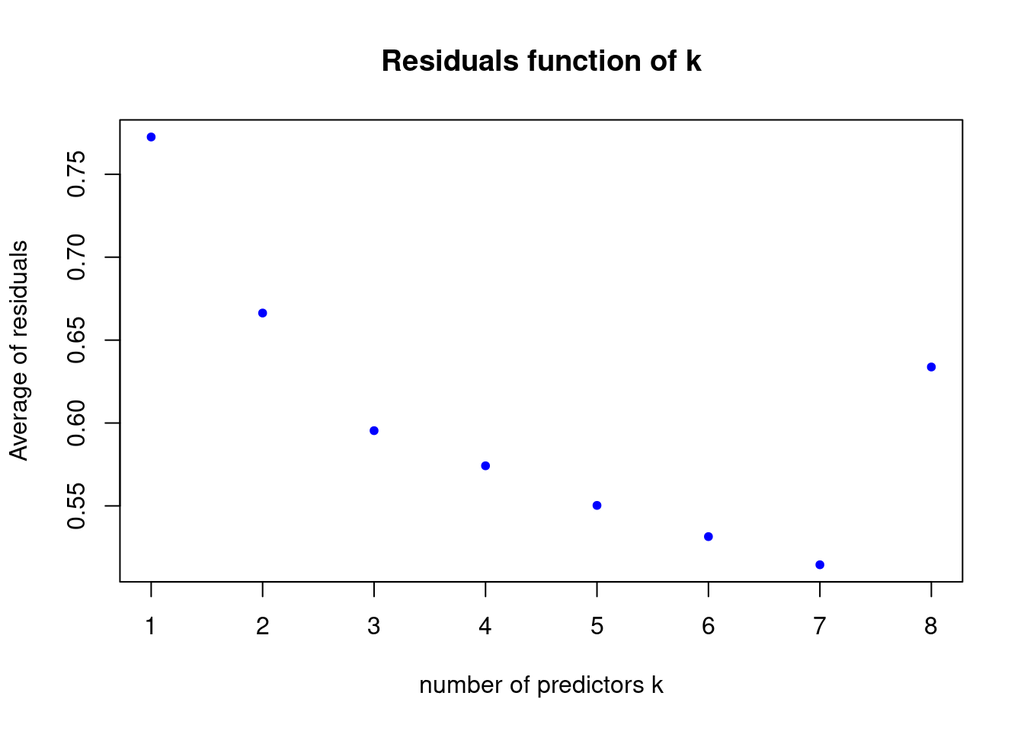

$\square$ We conclude that a model with $k=7$ predictors is optimal according to the split validation selection process. This method provides a different result than the minimum squared error in the previous exercise, all for the best, the model with $7$ predictors generalizes the best.

### (f)

$\square$ The main limitation of split-validation is that it can lead to overfitting if the data is not representative of the overall population.

$\bullet$ For example, In the cancer dataset, when we split the data into a training and validation set, there is a possibility that the training set may not contain enough representative samples of a particular class of cancer patients, resulting in poor performance on the validation set. A concrete example might be the fact that the predictor gleason contains only 1 example with level 8, which means the category “gleason = 8” is not well represented in our dataset.

$\bullet$ To address this problem, a common technique is to use cross-validation instead of split-validation. In k-fold cross-validation, the data is divided into k subsets, and the model is trained and tested k times, with each subset serving as the validation set once. This technique provides a more robust estimate of the model’s performance, as it uses all of the data for training and testing, and averages the results over k iterations.

$\square$ We will be implementing 3-fold cross-validation.

$\bullet$ For $k=1$

```
##   Predictor 1               RSS
## 1      lcavol 0.582043384212974
## 2     lweight  1.01127476515558
## 3         age   1.2076446070568
## 4        lbph  1.21533619107208
## 5         svi 0.826493826553129
## 6         lcp 0.852573036540521
## 7     gleason  0.97642464589548
## 8       pgg45  1.03836689045526
```

```
## Best choice of 1 predictors among 8:  lcavol
```

```
## The corresponding RSS is :  0.5820434
```

$\bullet$ For $k=2$

```
## Best choice of 2 predictors among 8:  lcavol  -  svi
```

```
## The corresponding RSS is :  0.5256654
```

$\bullet$ For $k=3$

```
## Best choice of 3 predictors among 8:  lcavol  -  lweight  -  svi
```

```
## The corresponding RSS is :  0.4818433
```

$\bullet$ For $k=4$

```
## Best choice of 4 predictors among 8:  lcavol  -  lweight  -  lbph  -  svi
```

```
## The corresponding RSS is :  0.4797148
```

$\bullet$ For $k=5$

```
## Best choice of 5 predictors among 8:  lcavol  -  lweight  -  age  -  lbph  -  svi
```

```
## The corresponding RSS is :  0.4745162
```

$\bullet$ For $k=6$

```
## Best choice of 6 predictors among 8:  lcavol  -  lweight  -  age  -  lbph  -  svi  -  gleason
```

```
## The corresponding RSS is :  0.476632
```

$\bullet$ For $k=7$

```
## Best choice of 7 predictors among 8:  lcavol  -  lweight  -  age  -  lbph  -  svi  -  lcp  -  gleason
```

```
## The corresponding RSS is :  0.4781924
```

$\bullet$ For $k=8$

```
## The RSS using all available predictors is :  0.5080237
```

$\square$ Again, The graph below sums up the results for the 3-fold cross-validation :

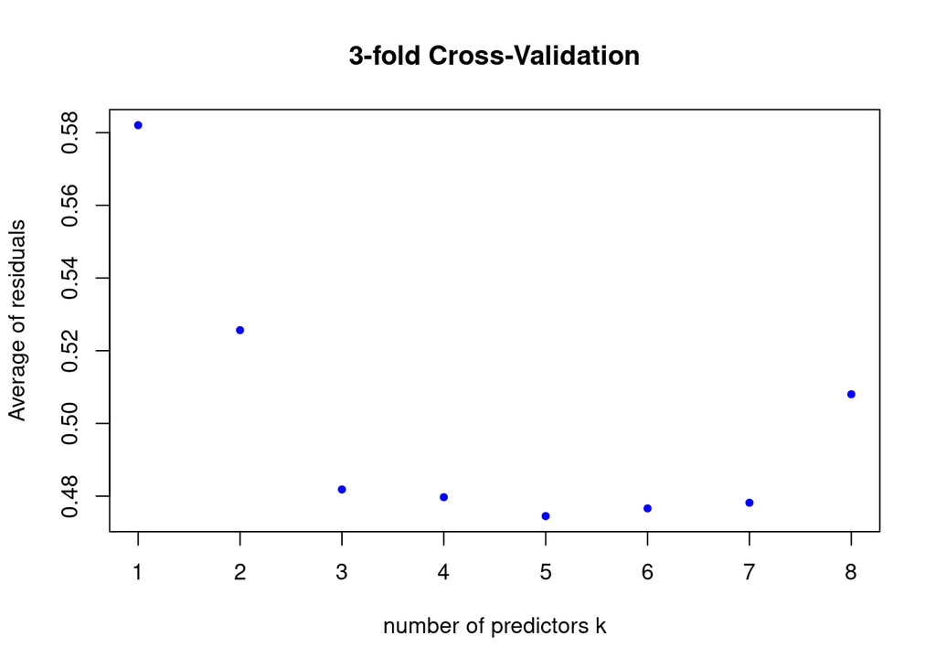

$\square$ From a model with 1 predictor to a model of two is a huge upgrade, going up to 5 improves our model again. Conversely, adding up more predictors further than five is a bad idea. The best model we can use is a model of size 5.

-> With split validation, we concluded that the best model was of size 7, Which again discredits the split-validation method. Indeed, by splitting our data, we created a boundary effect that introduced a bias in the results.

```
##
## Call:
## lm(formula = lpsa ~ ., data = prostateCancer[, c("lcavol", "lweight",
##     "age", "lbph", "svi", "lpsa")])
##
## Residuals:
##      Min       1Q   Median       3Q      Max
## -1.86717 -0.37725  0.01257  0.40252  1.44544
##
## Coefficients:
##             Estimate Std. Error t value Pr(>|t|)
## (Intercept)  0.49473    0.87652   0.564  0.57385
## lcavol       0.54400    0.07463   7.289 1.11e-10 ***
## lweight      0.58821    0.19790   2.972  0.00378 **
## age         -0.01644    0.01068  -1.540  0.12692
## lbph         0.10122    0.05759   1.758  0.08215 .
## svi1         0.71490    0.20653   3.461  0.00082 ***
## ---
## Signif. codes:  0 '***' 0.001 '**' 0.01 '*' 0.05 '.' 0.1 ' ' 1
##
## Residual standard error: 0.6988 on 91 degrees of freedom
## Multiple R-squared:  0.6526, Adjusted R-squared:  0.6335
## F-statistic: 34.19 on 5 and 91 DF,  p-value: < 2.2e-16
```

$\bullet$ One point that was not considered in this study is the trade-off between computation time and the model size. In fact, it doesn’t matter in this case because with 10 variables at most, the computation time would be small anyway.

###Question 5 : Ridge Regression

```r
library(glmnet)
set.seed(2523)
test=(1:nrow(prostateCancer)) %% 4 == 0

#define response variable
y <- prostateCancer$lpsa

#define matrix of predictor variables
x <- data.matrix(prostateCancer[, c('lcavol', 'lweight', 'age', 'lbph','svi','lcp','gleason','pgg45')])


#fit ridge regression model
model <- glmnet(x, y, alpha = 0)

#view summary of model
model
```

```
##
## Call:  glmnet(x = x, y = y, alpha = 0)
##
##     Df  %Dev Lambda
## 1    8  0.00 843.40
## 2    8  0.51 768.50
## 3    8  0.56 700.20
## 4    8  0.62 638.00
## 5    8  0.68 581.30
## 6    8  0.74 529.70
## 7    8  0.81 482.60
## 8    8  0.89 439.80
## 9    8  0.98 400.70
## 10   8  1.07 365.10
## 11   8  1.17 332.70
```

[output cut: 89 more lines]

```r
summary(model)
```

```
##           Length Class     Mode
## a0        100    -none-    numeric
## beta      800    dgCMatrix S4
## df        100    -none-    numeric
## dim         2    -none-    numeric
## lambda    100    -none-    numeric
## dev.ratio 100    -none-    numeric
## nulldev     1    -none-    numeric
## npasses     1    -none-    numeric
## jerr        1    -none-    numeric
## offset      1    -none-    logical
## call        4    -none-    call
## nobs        1    -none-    numeric
```

```r
#we perform 10-fold cross-validation to find optimal lambda value
#find optimal lambda value that minimizes ranging from 10^{-2} to 10^{10} test MSE


lambdas <- 10^seq(-2,10,by =1)
cv_ridge_reg = cv.glmnet(x,y, alpha = 0,lambda = lambdas,nfolds = 10)
best_lambda <- cv_ridge_reg$lambda.min
best_lambda
```

```
## [1] 0.1
```

The best value for lambda is 0.1 . We used cv.glmnet in order to choose lambda by cross validation in our grid of values. Now that we have found that 0.1 is the best lambda, we can build the model accordingly.

Let us predict values with the best model now and compute the MSE :

```r
cv_model <- glmnet(x, y, alpha = 0, lambda = 0.1)
y_predicted <- predict(cv_model, s = 0.1, newx = x)
mse <- sqrt(mean((y_predicted - y)^2))
mse
```

```
## [1] 0.6715099
```

###Question 6 : Lasso

We will now try to implement lasso regression. Firstly we use cross-validation to find the best value of lambda. The code will be very similar to the previous one, we just need to adjust a couple details in the cv.glmnet function.

```r
lasso_reg_lambda <- cv.glmnet(data.matrix(prostateCancer),prostateCancer$lpsa, alpha = 1,lambda = lambdas,standardize = TRUE,nfolds = 10)
lasso_reg_lambda
```

```
##
## Call:  cv.glmnet(x = data.matrix(prostateCancer), y = prostateCancer$lpsa,      lambda = lambdas, nfolds = 10, alpha = 1, standardize = TRUE)
##
## Measure: Mean-Squared Error
##
##     Lambda Index   Measure        SE Nonzero
## min   0.01    13 0.0001075 2.509e-05       1
## 1se   0.01    13 0.0001075 2.509e-05       1
```

```r
set.seed(2523)
test=(1:nrow(prostateCancer)) %% 4 == 0

#define response variable
y <- prostateCancer$lpsa

#define matrix of predictor variables
x <- data.matrix(prostateCancer[, c('lcavol', 'lweight', 'age', 'lbph','svi','lcp','gleason','pgg45')])


#fit ridge regression model
model <- glmnet(x, y, alpha = 1,standardize=TRUE)

#view summary of model
summary(model)
```

```
##           Length Class     Mode
## a0         70    -none-    numeric
## beta      560    dgCMatrix S4
## df         70    -none-    numeric
## dim         2    -none-    numeric
## lambda     70    -none-    numeric
## dev.ratio  70    -none-    numeric
## nulldev     1    -none-    numeric
## npasses     1    -none-    numeric
## jerr        1    -none-    numeric
## offset      1    -none-    logical
## call        5    -none-    call
## nobs        1    -none-    numeric
```

```r
#we perform 10-fold cross-validation to find optimal lambda value
#find optimal lambda value that minimizes ranging from 10^{-2} to 10^{10} test MSE


lambdas <- 10^seq(-2,10,by =1)
cv_ridge_reg = cv.glmnet(x,y, alpha = 1,lambda = lambdas,standardize = TRUE, nfolds = 10)
best_lambda <- cv_ridge_reg$lambda.min
best_lambda
```

```
## [1] 0.01
```

For the Lasso regression with cross-validation, we find that the best value for lambda is 0.01.

Let us build the according model :

```r
cv_model <- glmnet(x, y, alpha = 1,standardize = TRUE, lambda = 0.01)
y_predicted <- predict(cv_model, s = 0.01, newx = x)
mse <- sqrt(mean((y_predicted - y)^2))
mse
```

```
## [1] 0.6678499
```

We have found an MSE of 0.668, which is slightly better than with the Ridge Regression model.

###Question 7 : Principal component regression

For this question and for the sake of simplicity, I will use the package pls to perform the PCR as it does the cross validation on its own.

```r
library(pls)
pcr_model <- pcr(lpsa~., data = prostateCancer, ncomp = 9, validation = "CV")
summary(pcr_model)
```

```
## Data:    X dimension: 97 10
##  Y dimension: 97 1
## Fit method: svdpc
## Number of components considered: 9
##
## VALIDATION: RMSEP
## Cross-validated using 10 random segments.
##        (Intercept)  1 comps  2 comps  3 comps  4 comps  5 comps  6 comps
## CV            1.16    1.073    1.103    1.100   0.8663   0.7937   0.7941
## adjCV         1.16    1.071    1.100    1.095   0.8626   0.7900   0.7903
##        7 comps  8 comps  9 comps
## CV      0.7588   0.7446   0.7531
## adjCV   0.7544   0.7400   0.7481
##
## TRAINING: % variance explained
##       1 comps  2 comps  3 comps  4 comps  5 comps  6 comps  7 comps  8 comps
## X       93.48    99.46    99.69    99.89    99.95    99.97    99.99   100.00
## lpsa    18.00    18.25    27.53    52.43    60.20    60.74    65.32    67.12
##       9 comps
## X      100.00
## lpsa    67.12
```

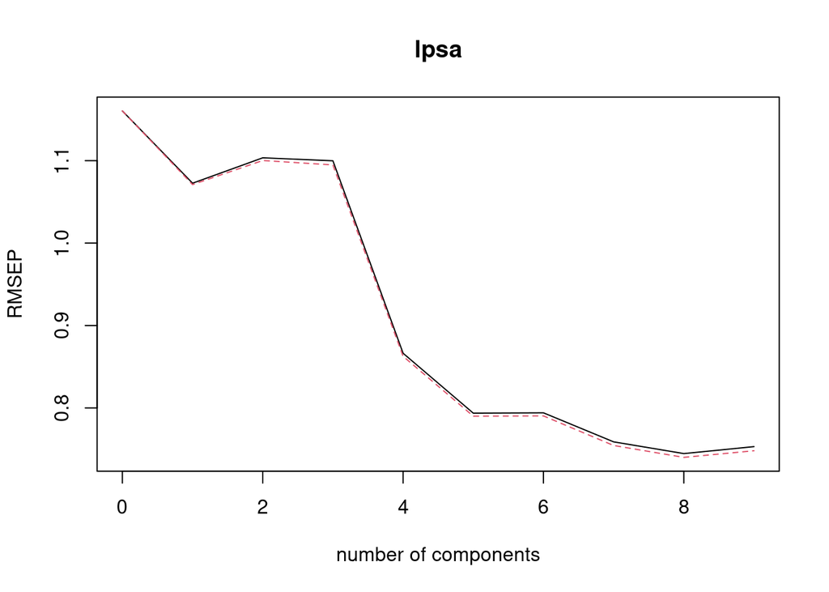

```r
validationplot(pcr_model)
```

We obtain a minimal MSE for 8 components (0.745)

###Question 8 : Partial least squares

$\bullet$Partial least squares method is another dimension reduction regression method, as PCR. The main difference between the two is that PCR is an unsupervised method, meaning the dimension reduction process use no information about the nature of the data. The difference with PLS is that the dimension reduction will be supervised and it will be much better than the PCR in the datasets where the target is correlated with directions with low variance. Note that the cross validation is also automatically performed within the function.

```r
pls_model <- plsr(lpsa~., data = prostateCancer, scale = FALSE, validation = "CV")
summary(pls_model)
```

```
## Data:    X dimension: 97 10
##  Y dimension: 97 1
## Fit method: kernelpls
## Number of components considered: 10
##
## VALIDATION: RMSEP
## Cross-validated using 10 random segments.
##        (Intercept)  1 comps  2 comps  3 comps  4 comps  5 comps  6 comps
## CV            1.16    1.057    1.041   0.8010   0.7647   0.7545   0.7484
## adjCV         1.16    1.056    1.062   0.7984   0.7606   0.7529   0.7435
##        7 comps  8 comps  9 comps  10 comps
## CV      0.7420   0.7454   0.7477    0.7464
## adjCV   0.7378   0.7408   0.7428    0.7416
##
## TRAINING: % variance explained
##       1 comps  2 comps  3 comps  4 comps  5 comps  6 comps  7 comps  8 comps
## X       93.47    98.49    99.67    99.76    99.94    99.96    99.98    100.0
## lpsa    18.20    26.99    57.00    63.09    64.56    67.00    67.16     67.2
##       9 comps  10 comps
## X      100.00    100.00
## lpsa    67.31     67.31
```

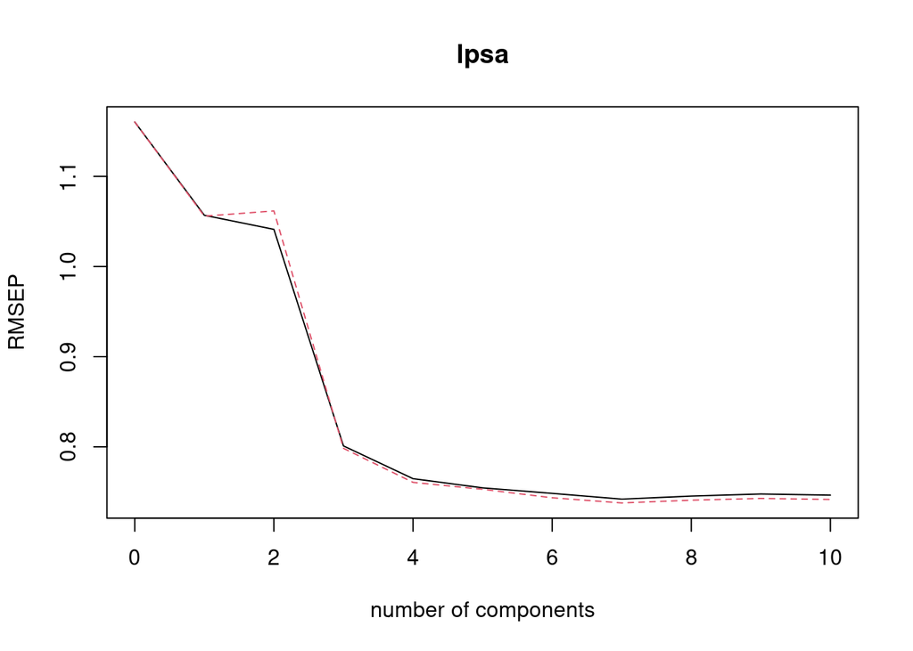

```r
validationplot(pls_model)
```

We obtain a minimal MSE for 7 components (0.737). The minimal MSE is inferior to that of the PCR model, which confirms that PLS can be an improvement of the PCR model.

###Question 9 : Cross-validation

###Question 10 : Conclusion

As a conclusion, we can conclude that the best models were obtained through the initial component selection via cross-validation in the question 4. Although, some of the methods used later were quite promising and much easier to ease with very acceptable MSE as we could have with the Lasso regression for example.

####Part 2 : Classification methods for the Weekly data set

In this exercise, we will be working over the Weekly dataset which consists of percentage returns for the S&P 500 stock index over 1089 weeks from the beginning of 1990 to the end of 2010. For each weeks, we have recorded the percentage returns for each of the five previous trading weeks, Lag1 through Lag5. We have also recorded Volume (the number of shares traded on the previous week, in billions), Today (the percentage return on the date in question) and Direction (whether the market was Up or Down on this date). Our goal is to predict Direction (a qualitative response) using the other features.

```r
library(ISLR2)
data(Weekly)
str("Weekly")
```

```
##  chr "Weekly"
```

```r
attach(Weekly)
```

###Question 1 Numerical and graphical summaries

Firstly we try to get some global informations about our dataset to get an idea of its confguration and of the global interactions bbetween the different columns.

```r
summary(Weekly)
```

```
##       Year           Lag1               Lag2               Lag3
##  Min.   :1990   Min.   :-18.1950   Min.   :-18.1950   Min.   :-18.1950
##  1st Qu.:1995   1st Qu.: -1.1540   1st Qu.: -1.1540   1st Qu.: -1.1580
##  Median :2000   Median :  0.2410   Median :  0.2410   Median :  0.2410
##  Mean   :2000   Mean   :  0.1506   Mean   :  0.1511   Mean   :  0.1472
##  3rd Qu.:2005   3rd Qu.:  1.4050   3rd Qu.:  1.4090   3rd Qu.:  1.4090
##  Max.   :2010   Max.   : 12.0260   Max.   : 12.0260   Max.   : 12.0260
##       Lag4               Lag5              Volume            Today
##  Min.   :-18.1950   Min.   :-18.1950   Min.   :0.08747   Min.   :-18.1950
##  1st Qu.: -1.1580   1st Qu.: -1.1660   1st Qu.:0.33202   1st Qu.: -1.1540
##  Median :  0.2380   Median :  0.2340   Median :1.00268   Median :  0.2410
##  Mean   :  0.1458   Mean   :  0.1399   Mean   :1.57462   Mean   :  0.1499
##  3rd Qu.:  1.4090   3rd Qu.:  1.4050   3rd Qu.:2.05373   3rd Qu.:  1.4050
##  Max.   : 12.0260   Max.   : 12.0260   Max.   :9.32821   Max.   : 12.0260
##  Direction
##  Down:484
##  Up  :605
##
##
##
##
```

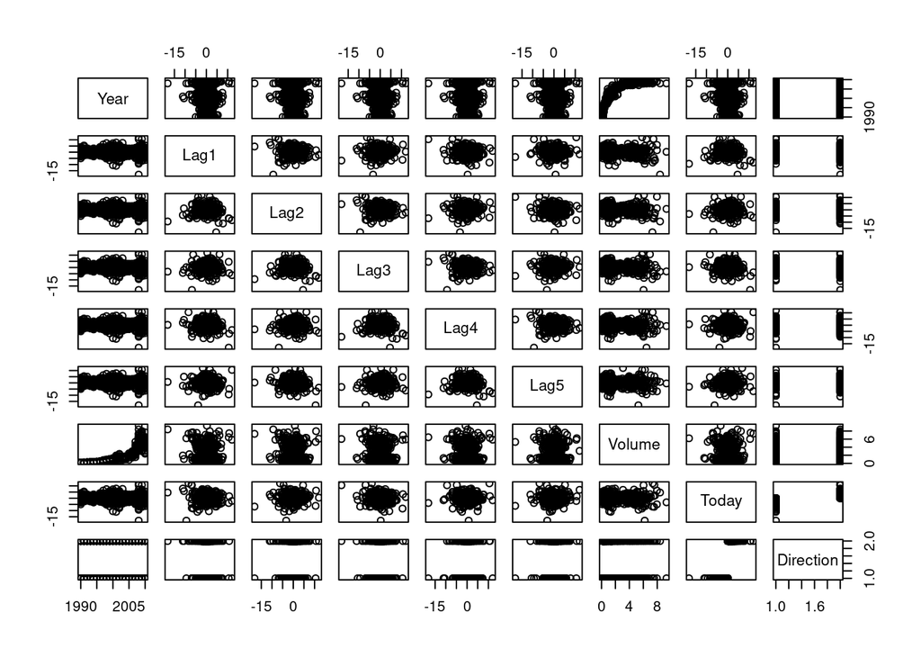

```r
pairs(Weekly)
```

```r
#As the values of the Direction column will be either "up" or "down", we remove the column to calculate the correlation
cor(Weekly[,-9])
```

```
##               Year         Lag1        Lag2        Lag3         Lag4
## Year    1.00000000 -0.032289274 -0.03339001 -0.03000649 -0.031127923
## Lag1   -0.03228927  1.000000000 -0.07485305  0.05863568 -0.071273876
## Lag2   -0.03339001 -0.074853051  1.00000000 -0.07572091  0.058381535
## Lag3   -0.03000649  0.058635682 -0.07572091  1.00000000 -0.075395865
## Lag4   -0.03112792 -0.071273876  0.05838153 -0.07539587  1.000000000
## Lag5   -0.03051910 -0.008183096 -0.07249948  0.06065717 -0.075675027
## Volume  0.84194162 -0.064951313 -0.08551314 -0.06928771 -0.061074617
## Today  -0.03245989 -0.075031842  0.05916672 -0.07124364 -0.007825873
##                Lag5      Volume        Today
## Year   -0.030519101  0.84194162 -0.032459894
## Lag1   -0.008183096 -0.06495131 -0.075031842
## Lag2   -0.072499482 -0.08551314  0.059166717
## Lag3    0.060657175 -0.06928771 -0.071243639
## Lag4   -0.075675027 -0.06107462 -0.007825873
## Lag5    1.000000000 -0.05851741  0.011012698
## Volume -0.058517414  1.00000000 -0.033077783
## Today   0.011012698 -0.03307778  1.000000000
```

It it rather hard to see something interesting with the “pairs” function, although there seem to be a logarithmic relation between the Year and Volume variable. This is confirmed by the correlation computation which actually returns a very high correlation between those two variables (+0,84). Most of the other correlations are rather low and there is nothing more interesting at first glance.

###Question 2 : Logistic regression

```r
Weekly_log<-glm(Direction~Lag1+Lag2+Lag3+Lag4+Lag5+Volume, data=Weekly,family=binomial)
summary(Weekly_log)
```

```
##
## Call:
## glm(formula = Direction ~ Lag1 + Lag2 + Lag3 + Lag4 + Lag5 +
##     Volume, family = binomial, data = Weekly)
##
## Deviance Residuals:
##     Min       1Q   Median       3Q      Max
## -1.6949  -1.2565   0.9913   1.0849   1.4579
##
## Coefficients:
##             Estimate Std. Error z value Pr(>|z|)
## (Intercept)  0.26686    0.08593   3.106   0.0019 **
## Lag1        -0.04127    0.02641  -1.563   0.1181
## Lag2         0.05844    0.02686   2.175   0.0296 *
## Lag3        -0.01606    0.02666  -0.602   0.5469
## Lag4        -0.02779    0.02646  -1.050   0.2937
## Lag5        -0.01447    0.02638  -0.549   0.5833
## Volume      -0.02274    0.03690  -0.616   0.5377
## ---
## Signif. codes:  0 '***' 0.001 '**' 0.01 '*' 0.05 '.' 0.1 ' ' 1
##
## (Dispersion parameter for binomial family taken to be 1)
##
##     Null deviance: 1496.2  on 1088  degrees of freedom
## Residual deviance: 1486.4  on 1082  degrees of freedom
## AIC: 1500.4
##
## Number of Fisher Scoring iterations: 4
```

Only one parameter seems to be significant at the level of significance alpha =0.05 : Lag2. The other variables fail the test.

###Question 3 : Confusion matrix

```r
#We predict our values
Weekly_log_pred = predict(Weekly_log, type='response')
#If the predicted value is <0.5, the prediction is "Down", else, the prediction is "Up" so we make a vector accordingly
Weekly_log_pred2 =rep("Down", length(Weekly_log_pred))
Weekly_log_pred2[Weekly_log_pred > 0.5] = "Up"
#We can now compute the confusion matrix
table(Weekly_log_pred2, Direction)
```

```
##                 Direction
## Weekly_log_pred2 Down  Up
##             Down   54  48
##             Up    430 557
```

The confusion matrix gives us information about the percentage of right and wrong prediction. Basically, We got right 54 “Down” Prediction but predicted “Down” 48 times when it was actually “Up” We predicted “Up” 557 times right but 430 times, we predicted “Up” when it was actually down.

Hence, we have $(54+557)/(54+48+430+557)*100 = 56.1\%$ of global prediction accuracy It is interesting to notice that when we need to predict “Down”, we have $54/484 *100 = 11.16\%$ of success so our method is very poor in that regard. But when we want to predict “Up”, we have $557/605 * 100 = 92.1\%$ of accuracy which is contrastly really high.

###Question 4 : Logistic regression and confusion matrix

Now, we will split the data set into a training and validation set. We will use the data from 1990 to 2008 as our training set and the rest as our validation set. We will compute the confusion matrix with that values doing the predictions on the validation set data.

```r
#Computing the model based on the training dataset
train = (Year<2009)
Weekly_test <-Weekly[!train,]
Weekly_train <-Weekly[train,]
Weekly_model_log<-glm(Direction~Lag2, data=Weekly_train,family=binomial)

#Predicting for the validation set
Weekly_log_pred = predict(Weekly_model_log, Weekly_test, type = "response")

#Confusion Matrix
Weekly_log_pred2 = rep("Down", length(Weekly_log_pred))
Weekly_log_pred2[Weekly_log_pred > 0.5] = "Up"
Direction_test = Direction[!train]

table(Weekly_log_pred2, Direction_test)
```

```
##                 Direction_test
## Weekly_log_pred2 Down Up
##             Down    9  5
##             Up     34 56
```

Now we got a significant improvement using this method. Our global accuracy has now risen to 62.5% (It was previously 56.1%). Our accuracy when predicting “Up” has very slightly disminished with 91.8% of accuracy (Previously 92.1%). Our accuracy when predicting “Down” has significantly increased (while still remaining rather low) with 20.9% of accuracy (Previously 11.2%).

###Question 5 : Linear Discriminant Analysis

We will now do the same as question 4 but using LDA.

```r
library(MASS)
#Computing the model based on the training dataset

train = (Year<2009)
Weekly_test <-Weekly[!train,]
Weekly_train <-Weekly[train,]
Weekly_model_lda<-lda(Direction~Lag2, data=Weekly_train,family=binomial)

#Predicting for the validation set
Weekly_lda_pred = predict(Weekly_model_lda, Weekly_test)

#One can note that in this case, we directly predicted "Up" or "Down", not a value between 0 and 1
#Confusion Matrix
table(Weekly_lda_pred$class, Direction_test)
```

```
##       Direction_test
##        Down Up
##   Down    9  5
##   Up     34 56
```

This method didn’t give us any new insights as the results are exactly the same as those we had in Question 4.

###Question 6 : Quadratic discriminant analysis

We will now try to use QDA, with practically the same code as Question 5.

```r
library(MASS)
#Computing the model based on the training dataset

train = (Year<2009)
Weekly_test <-Weekly[!train,]
Weekly_train <-Weekly[train,]
Weekly_model_qda<-qda(Direction~Lag2, data=Weekly_train,family=binomial)

#Predicting for the validation set
Weekly_qda_pred = predict(Weekly_model_qda, Weekly_test)

#One can note that in this case, we directly predicted "Up" or "Down", not a value between 0 and 1
#Confusion Matrix
table(Weekly_qda_pred$class, Direction_test)
```

```
##       Direction_test
##        Down Up
##   Down    0  0
##   Up     43 61
```

The accuracy is of 58.65% but this model has basically given “Up” all the time and this percentage is most likely due to the distribution of our validation set and nothing else. It doesn’t seem to be granting us any information or improvement.

###Question 7 : K_Nearest Neighbors

We will now try to use the KNN method with K = 1 to see if it grants us any interesting results.

```r
library(class)

train = (Year<2009)

#We have to turn our objects into vectors or data frames to use the function
Weekly_train = as.matrix(Lag2[train])
Weekly_test = as.matrix(Lag2[!train])
Direction_train = Direction[train]
Direction_test = Direction[!train]

Weekly_1nn_pred = knn(Weekly_train,Weekly_test, Direction_train ,k=1)
table(Weekly_1nn_pred, Direction_test)
```

```
##                Direction_test
## Weekly_1nn_pred Down Up
##            Down   21 30
##            Up     22 31
```

This method gives approximately 51% of success globally and for each variable. We do not get any improvement from it and the distribution of the values is rather uninteresting.

###Question 8 : Naive Bayes

We will now try to use the Naive Bayes method.

```r
library(e1071)

train = (Year<2009)

#We have to turn our objects into vectors or data frames to use the function
Weekly_test <-Weekly[!train,]
Weekly_train <-Weekly[train,]
Direction_train = Direction[train]
Direction_test = Direction[!train]

Weekly_model_bayes = naiveBayes(Direction~.,data = Weekly_train)

Weekly_bayes_pred = predict(Weekly_model_bayes, Weekly_test)

table(Weekly_bayes_pred, Direction_test)
```

```
##                  Direction_test
## Weekly_bayes_pred Down Up
##              Down   43 15
##              Up      0 46
```

We obtain a very impressive improvement using this method, the “Up” prediction has 100% of success, the “Down” prediction has about 74% of success. We have a global success rate of 85.6% which is far superior to every method that we have previously tried.

###Question 9 : Comparison

On this data, the Naive Bayes gave us by far the most promising results with about 85% of accuracy, it is followed by LDA and Logistic regression with 62.5%, QDA with 59% but given the nature of the results I think it is not relevant and this high percentage is purely random. Then we finally have 1NN which gave us about 50% which makes it uninteresting. The great success of NaiveBayes could indicate that the predictors were independent which would put us in the best conditions for the optimality of this method.

###Question 10 : Experiment with different combinations of predictors

We will now try to use different combinations of predictors for the different methods and try to see if we find better methods For a simplicity matter, I will try out a couple of different combinations but I will not do all of them.

```r
#Logistic Regression with the predictors Lag3 and Lag5

Weekly_test <-Weekly[!train,]
Weekly_train <-Weekly[train,]
Direction_train = Direction[train]
Direction_test = Direction[!train]


Weekly_model<-glm(Direction~Lag3 +Lag5, data=Weekly_train, family=binomial)
Weekly_log_pred = predict(Weekly_model, Weekly_test, type = "response")
Weekly_log_pred2 = rep("Down", length(Weekly_log_pred))
Weekly_log_pred2[Weekly_log_pred > 0.5] = "Up"

table(Weekly_log_pred2, Direction_test)
```

```
##                 Direction_test
## Weekly_log_pred2 Down Up
##             Down    1  3
##             Up     42 58
```

With predictors 3 and 5 and logistic regression we get a very poor model as the prediction is almost always “Up”, it seems rather irrelevant.

```r
#Logistic Regression with the predictors Lag2, Lag3 and Lag5

Weekly_test <-Weekly[!train,]
Weekly_train <-Weekly[train,]
Direction_train = Direction[train]
Direction_test = Direction[!train]


Weekly_model<-glm(Direction~Lag2+Lag3 +Lag5, data=Weekly_train, family=binomial)
Weekly_log_pred = predict(Weekly_model, Weekly_test, type = "response")
Weekly_log_pred2 = rep("Down", length(Weekly_log_pred))
Weekly_log_pred2[Weekly_log_pred > 0.5] = "Up"

table(Weekly_log_pred2, Direction_test)
```

```
##                 Direction_test
## Weekly_log_pred2 Down Up
##             Down    7  4
##             Up     36 57
```

This is a bit better than before but still gives “Up” way too much.

```r
#QDA with the predictors Lag2 and Volume

Weekly_test <-Weekly[!train,]
Weekly_train <-Weekly[train,]
Direction_train = Direction[train]
Direction_test = Direction[!train]


Weekly_model<-qda(Direction~Lag2+Volume, data=Weekly_train,family=binomial)
Weekly_log_pred = predict(Weekly_model, Weekly_test, type = "response")


table(Weekly_qda_pred$class, Direction_test)
```

```
##       Direction_test
##        Down Up
##   Down    0  0
##   Up     43 61
```

Let us try to use KNN with various values of k.

```r
library(class)
set.seed(2523)
train = (Year<2009)

#We will try to use KNN with various values of k

Weekly_train = as.matrix(Lag2[train])
Weekly_test = as.matrix(Lag2[!train])
Direction_train = Direction[train]
Direction_test = Direction[!train]


Weekly_1nn_pred = knn(Weekly_train,Weekly_test, Direction_train ,k=1)
table(Weekly_1nn_pred, Direction_test)
```

```
##                Direction_test
## Weekly_1nn_pred Down Up
##            Down   21 29
##            Up     22 32
```

```r
Weekly_2nn_pred = knn(Weekly_train,Weekly_test, Direction_train ,k=2)
table(Weekly_2nn_pred, Direction_test)
```

```
##                Direction_test
## Weekly_2nn_pred Down Up
##            Down   19 25
##            Up     24 36
```

```r
Weekly_3nn_pred = knn(Weekly_train,Weekly_test, Direction_train ,k=3)
table(Weekly_3nn_pred, Direction_test)
```

```
##                Direction_test
## Weekly_3nn_pred Down Up
##            Down   16 20
##            Up     27 41
```

```r
Weekly_5nn_pred = knn(Weekly_train,Weekly_test, Direction_train ,k=5)
table(Weekly_5nn_pred, Direction_test)
```

```
##                Direction_test
## Weekly_5nn_pred Down Up
##            Down   15 21
##            Up     28 40
```

```r
Weekly_7nn_pred = knn(Weekly_train,Weekly_test, Direction_train ,k=7)
table(Weekly_7nn_pred, Direction_test)
```

```
##                Direction_test
## Weekly_7nn_pred Down Up
##            Down   15 20
##            Up     28 41
```

```r
Weekly_10nn_pred = knn(Weekly_train,Weekly_test, Direction_train ,k=10)
table(Weekly_10nn_pred, Direction_test)
```

```
##                 Direction_test
## Weekly_10nn_pred Down Up
##             Down   18 18
##             Up     25 43
```

```r
Weekly_11nn_pred = knn(Weekly_train,Weekly_test, Direction_train ,k=11)
table(Weekly_11nn_pred, Direction_test)
```

```
##                 Direction_test
## Weekly_11nn_pred Down Up
##             Down   19 22
##             Up     24 39
```

One interesting thing now is that the KNN method gets better for some values of k and it is not as random as it seemed to be with k = to 1. For the values that we tried, we get the best results for K=10 with 58.7 success rate, 50% chance when guessing “Down” and 63% when guessing “Up” which is quite fine comparing with 1NN.

```r
library(e1071)

train = (Year<2009)
#train = (Year<2007)

#We have to turn our objects into vectors or data frames to use the function
Weekly_test <-Weekly[!train,]
Weekly_train <-Weekly[train,]
Direction_train = Direction[train]
Direction_test = Direction[!train]

Weekly_model_bayes = naiveBayes(Direction~Lag2+ Lag5 +Lag4+ Today ,data = Weekly_train)
Weekly_bayes_pred = predict(Weekly_model_bayes, Weekly_test)
table(Weekly_bayes_pred, Direction_test)
```

```
##                  Direction_test
## Weekly_bayes_pred Down Up
##              Down   41  0
##              Up      2 61
```

```r
Weekly_model_bayes = naiveBayes(Direction~Lag2+ Volume+ Lag5 +Lag4+ Today ,data = Weekly_train)
Weekly_bayes_pred = predict(Weekly_model_bayes, Weekly_test)
table(Weekly_bayes_pred, Direction_test)
```

```
##                  Direction_test
## Weekly_bayes_pred Down Up
##              Down   43 11
##              Up      0 50
```

```r
Weekly_model_bayes = naiveBayes(Direction~ Lag4+ Today  +Lag1 ,data = Weekly_train)
Weekly_bayes_pred = predict(Weekly_model_bayes, Weekly_test)
table(Weekly_bayes_pred, Direction_test)
```

```
##                  Direction_test
## Weekly_bayes_pred Down Up
##              Down   43  1
##              Up      0 60
```

I have now tried to use the naive Bayes method with various predictors and the results are really interesting this time.

One remark here is that Volume seem to affect the efficiency of the model really much, maybe it does not satisfy the assumptions of naive Bayes really well ?

-With predictors Lag1, Lag4 and Today, we have the most success rate with only one “Down” guessed wrongly for more than 99% success rate.

Note : for the sake of curiosity i have tried another testing set to make sure that the results would remain very high, it can be found in the comments of the code and also gives results close to 99% of success for the best models.

Eventually, trying out some methods did lead to very interesting results and we still have naiveBayes as the most efficient method this time with nearly 100%, reaching a peak efficiency with predictors Lag1, Lag4 and Today. We can remark that we got some success using KNN with $K=10$ with about 58% of success even though it is not a very great model still. The others attempts on QDA and Logistic regression were rather disappointing and lead to nothing interesting.

As a conclusion, we can say that naiveBayes with the right choice of predictors was, by far, the best model that we have found.

####Part3 : Decision Trees for the Carseats data set

```r
library(ISLR2)
data(Carseats)
str("Carseats")
```

```
##  chr "Carseats"
```

```r
attach(Carseats)
Carseats$Name<-NULL
```

Remark : In the following questions, I happened to encounter an issue regarding a random factor in the results, in fact, when using the tree library function, the results can slightly vary on my side if I rerun the program and setting the seed again (which I thought was initially the issue) didn’t quite seem to do the trick, it sometimes change and it sometimes does not, so if some results is slightly different in my explanations and a plot this might be the reason.

###Question 1 : Split the data

```r
library(tree)
summary(Carseats)
```

```
##      Sales          CompPrice       Income        Advertising
##  Min.   : 0.000   Min.   : 77   Min.   : 21.00   Min.   : 0.000
##  1st Qu.: 5.390   1st Qu.:115   1st Qu.: 42.75   1st Qu.: 0.000
##  Median : 7.490   Median :125   Median : 69.00   Median : 5.000
##  Mean   : 7.496   Mean   :125   Mean   : 68.66   Mean   : 6.635
##  3rd Qu.: 9.320   3rd Qu.:135   3rd Qu.: 91.00   3rd Qu.:12.000
##  Max.   :16.270   Max.   :175   Max.   :120.00   Max.   :29.000
##    Population        Price        ShelveLoc        Age          Education
##  Min.   : 10.0   Min.   : 24.0   Bad   : 96   Min.   :25.00   Min.   :10.0
##  1st Qu.:139.0   1st Qu.:100.0   Good  : 85   1st Qu.:39.75   1st Qu.:12.0
##  Median :272.0   Median :117.0   Medium:219   Median :54.50   Median :14.0
##  Mean   :264.8   Mean   :115.8                Mean   :53.32   Mean   :13.9
##  3rd Qu.:398.5   3rd Qu.:131.0                3rd Qu.:66.00   3rd Qu.:16.0
##  Max.   :509.0   Max.   :191.0                Max.   :80.00   Max.   :18.0
##  Urban       US
##  No :118   No :142
##  Yes:282   Yes:258
##
##
##
##
```

```r
#This will define the test sample, we will use a quarter of the values
test=(1:nrow(Carseats)) %% 4 == 0
```

###Question 2 : Fit a regression tree to the training set

In this part, I will build a regression tree over my dataset and try to predict the value of Sales according to the other parameters.

```r
library(tree)
summary(Carseats)
```

```
##      Sales          CompPrice       Income        Advertising
##  Min.   : 0.000   Min.   : 77   Min.   : 21.00   Min.   : 0.000
##  1st Qu.: 5.390   1st Qu.:115   1st Qu.: 42.75   1st Qu.: 0.000
##  Median : 7.490   Median :125   Median : 69.00   Median : 5.000
##  Mean   : 7.496   Mean   :125   Mean   : 68.66   Mean   : 6.635
##  3rd Qu.: 9.320   3rd Qu.:135   3rd Qu.: 91.00   3rd Qu.:12.000
##  Max.   :16.270   Max.   :175   Max.   :120.00   Max.   :29.000
##    Population        Price        ShelveLoc        Age          Education
##  Min.   : 10.0   Min.   : 24.0   Bad   : 96   Min.   :25.00   Min.   :10.0
##  1st Qu.:139.0   1st Qu.:100.0   Good  : 85   1st Qu.:39.75   1st Qu.:12.0
##  Median :272.0   Median :117.0   Medium:219   Median :54.50   Median :14.0
##  Mean   :264.8   Mean   :115.8                Mean   :53.32   Mean   :13.9
##  3rd Qu.:398.5   3rd Qu.:131.0                3rd Qu.:66.00   3rd Qu.:16.0
##  Max.   :509.0   Max.   :191.0                Max.   :80.00   Max.   :18.0
##  Urban       US
##  No :118   No :142
##  Yes:282   Yes:258
##
##
##
##
```

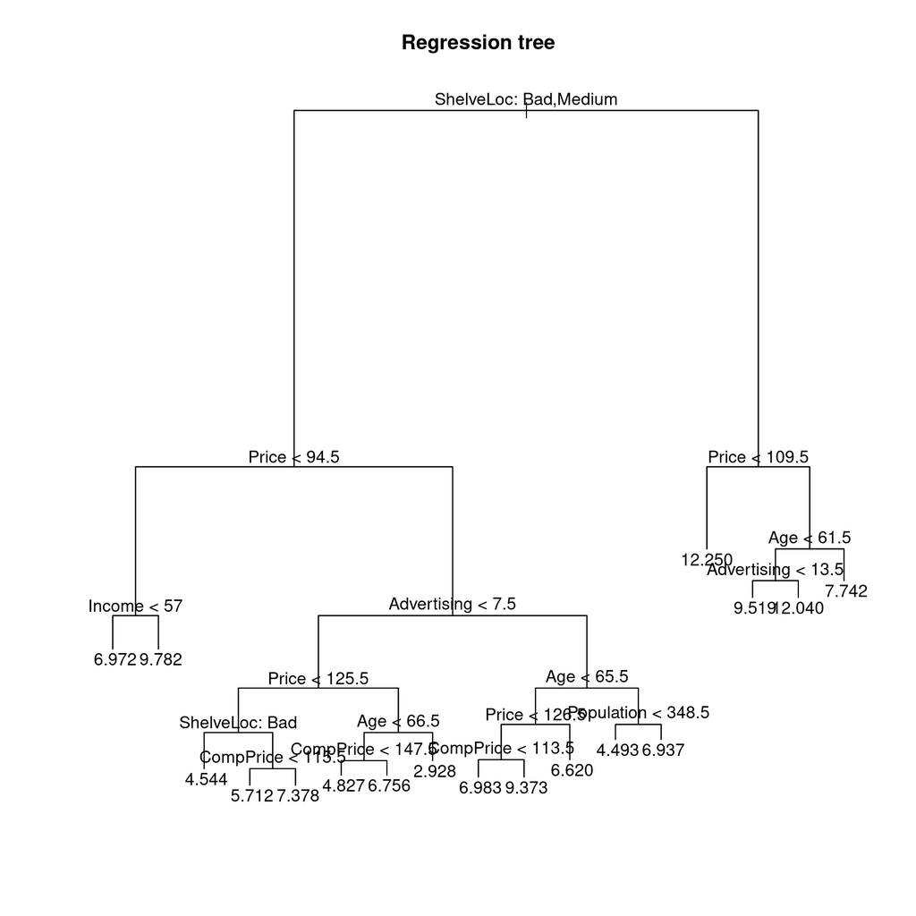

```r
set.seed(2523)



tree_carseats = tree(Sales~.,data = Carseats[!test,])



plot(tree_carseats)
text(tree_carseats, pretty = 0, xpd = TRUE)
title("Regression tree")
```

```r
tree_pred=predict(tree_carseats, Carseats[test,])

sqrt(mean((tree_pred - Carseats$Sales)^2))
```

```
## [1] 3.530104
```

###Question 3 : Optimal level of tree complexity

We will try to perform cross-validation using cv.tree function to see if we can prune the tree into an actually better model.

```r
set.seed(2523)
cv_carseats =cv.tree(tree_carseats )
names(cv_carseats )
```

```
## [1] "size"   "dev"    "k"      "method"
```

```r
cv_carseats
```

```
## $size
##  [1] 17 16 15 14 13 12 11 10  9  8  7  6  5  4  3  2  1
##
## $dev
##  [1] 1355.430 1411.395 1426.035 1450.207 1453.620 1461.688 1552.195 1609.846
##  [9] 1595.545 1607.401 1595.089 1606.508 1584.806 1834.250 1850.184 1957.092
## [17] 2519.725
##
## $k
##  [1]      -Inf  25.93970  26.86445  29.62757  30.00964  30.95744  50.22770
##  [8]  56.78339  59.69948  63.05773  64.48344  64.99420  79.50517 129.46139
## [15] 146.73637 265.99176 636.93579
##
## $method
## [1] "deviance"
##
## attr(,"class")
## [1] "prune"         "tree.sequence"
```

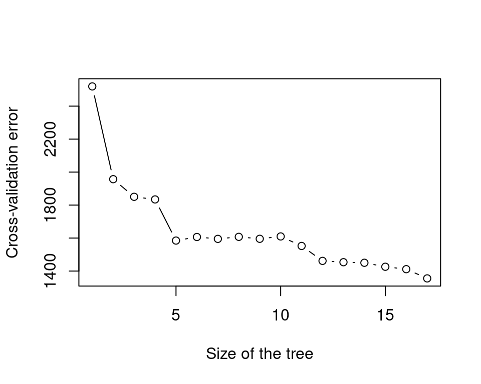

```r
plot(cv_carseats$size ,cv_carseats$dev ,xlab = "Size of the tree", ylab ="Cross-validation error",type="b")
```

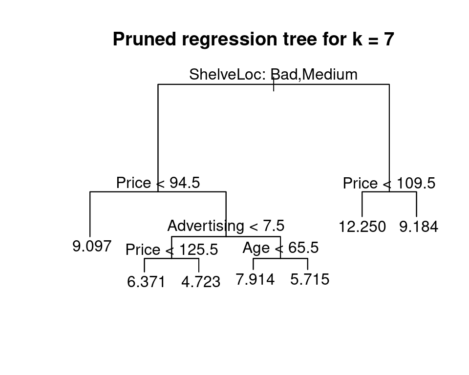

```r
prune_carseats =prune.tree(tree_carseats ,best =7)
plot(prune_carseats )
text(prune_carseats ,pretty =0)
title("Pruned regression tree for k = 7")
```

```r
tree_pred=predict(prune_carseats, Carseats[test,])

sqrt(mean((tree_pred - Carseats$Sales)^2))
```

```
## [1] 3.252993
```

###Question 4 : Classification trees on the training data

We have tried to predict our results using regression tree, we will now proceed to try and predict our results using a classification tree. Note that in order to do so, we need to turn the “Sales” column into a binary value, so basically, we will call “high” a sales value above 8 and “not high” otherwise (characterized by 0 and 1)

We now replaced the Sales values by a binary value (basically higher or lower) and we computed the tree accordingly.

We recall that for a classification tree, the deviance (as reported in the summary function) for a given statistical model m, with $n_{ij}$ the value of a node and $\hat{n}_{ij}$ the expected value of a node.
$$D(m) =
2\sum_{i=1}^r\sum_{j=1}^cn_{ij}ln(\frac{n_{ij}}{\hat{n}_{ij}})$$

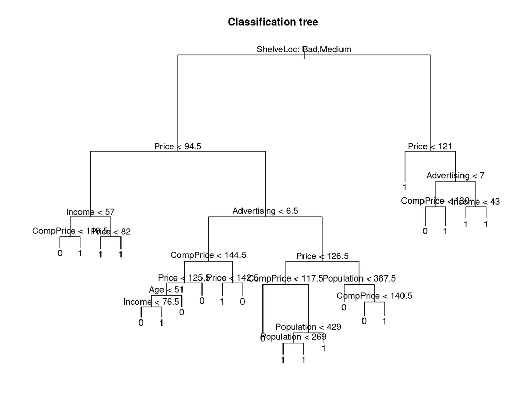

```r
Carseats$High=ifelse(Sales <=8,0,1)
Carseats$High<-factor(Carseats$High)
test=(1:nrow(Carseats)) %% 4 == 0

#As usual, we build the tree using the training set
tree_carseats_high = tree(High~.-Sales, data = Carseats[!test,])

#Plot
plot(tree_carseats_high )
text(tree_carseats_high ,pretty =0)
title("Classification tree")
```

```r
summary(tree_carseats_high)
```

```
##
## Classification tree:
## tree(formula = High ~ . - Sales, data = Carseats[!test, ])
## Variables actually used in tree construction:
## [1] "ShelveLoc"   "Price"       "Income"      "CompPrice"   "Advertising"
## [6] "Age"         "Population"
## Number of terminal nodes:  22
## Residual mean deviance:  0.5146 = 143 / 278
## Misclassification error rate: 0.1167 = 35 / 300
```

```r
#We make the predictions using the testing set
tree_pred=predict(tree_carseats_high ,Carseats[test,] ,type ="class")

t.table<-table(tree_pred ,Carseats[test,]$High)
t.table
```

```
##
## tree_pred  0  1
##         0 49 12
##         1 14 25
```

The training error rate given by the function summary() is 0.1167

As we now work on classification trees, the MSE does not seem like the right way to compare our results (our values are either zero or one). Hence, in order to make a comparison later, I computed the confusion matrix and I will simply compare the success rates.

###Question 5 : Classification trees on the testing data

This step has already been done previously and there is no need to change the arrangement of the training and testing sets so I will use the same ones thereafter.

###Question 6 : Optimal level of tree complexity

In order to improve our previous model even more, we would like to see if pruning can give us a better solution so we will reuse the cv.tree function in that regard.

```r
#We reuse the previous code to see if we can upgrade the tree by performing cross validation
set.seed(2523)
cv_carseats_high =cv.tree(tree_carseats_high ,FUN=prune.misclass )
names(cv_carseats_high )
```

```
## [1] "size"   "dev"    "k"      "method"
```

```r
cv_carseats_high
```

```
## $size
##  [1] 22 15 12 10  9  7  6  3  2  1
##
## $dev
##  [1]  82  82  76  76  73  77  77  83  91 127
##
## $k
##  [1] -Inf  0.0  1.0  1.5  2.0  3.0  4.0  6.0 17.0 39.0
##
## $method
## [1] "misclass"
##
## attr(,"class")
## [1] "prune"         "tree.sequence"
```

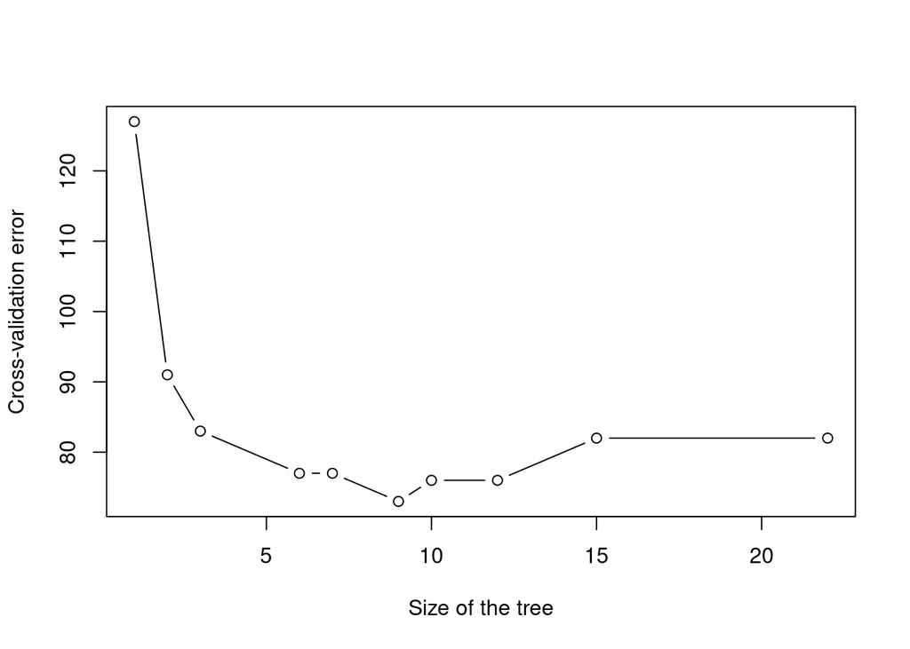

```r
plot(cv_carseats_high$size ,cv_carseats_high$dev ,xlab = "Size of the tree", ylab ="Cross-validation error",type="b")
```

Running this function and plotting the error against the size of the tree, we notice that there is in fact a pruned version of the tree that gives a much smaller cross-validation error with $k=9$ so we prune the tree accordingly.

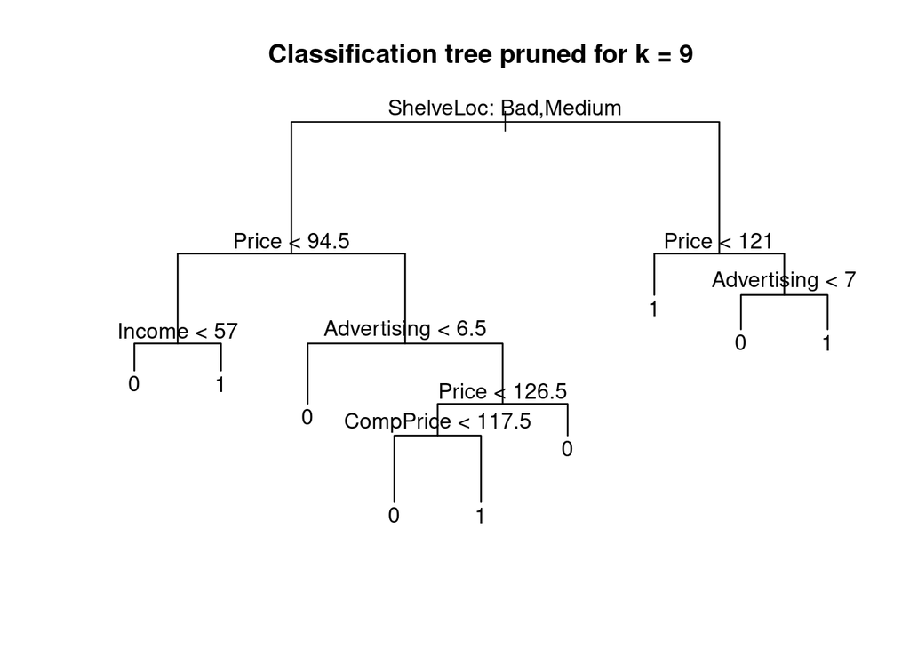

```r
#There is in fact a better pruning option in this case for k = 9, we will use this tree to compute the prediction
prune_carseats_high =prune.misclass(tree_carseats_high ,best =9)

plot(prune_carseats_high )
text(prune_carseats_high ,pretty =0)
title("Classification tree pruned for k = 9")
```

```r
summary(prune_carseats_high)
```

```
##
## Classification tree:
## snip.tree(tree = tree_carseats_high, nodes = c(9L, 15L, 45L,
## 8L, 10L, 23L, 14L))
## Variables actually used in tree construction:
## [1] "ShelveLoc"   "Price"       "Income"      "Advertising" "CompPrice"
## Number of terminal nodes:  9
## Residual mean deviance:  0.7954 = 231.5 / 291
## Misclassification error rate: 0.1433 = 43 / 300
```

```r
tree_pred_pruned=predict(tree_carseats_high ,Carseats[test,] ,type ="class")


t.table<-table(tree_pred_pruned ,Carseats[test,]$High)
t.table
```

```
##
## tree_pred_pruned  0  1
##                0 49 12
##                1 14 25
```